# **Data Mining on Four Sets of Data with Lasso Regression, Tree Based Approaches and SGB**

Kaan Bilgin

31/1/2021

# **1.Introduction**

# **2.Datasets**

**[Spambase Data Set](https://archive.ics.uci.edu/ml/datasets/spambase)**

- The “spam” concept is diverse: advertisements for products/web sites, make money fast schemes, chain letters etc. This dataset of includes spam mails and normal private mails data to come up with a filter for spam or not detection hence, spam or not classification.
  - Data Set Characteristics: Multivariate
  - Number of Instances: 4601
  - Attribute Characteristics: Integer, Real
  - Number of Attributes: 57
  - Associated Tasks: Binary Classification (Spam or Not)
  - Missing Values: Yes
  - Class Imbalance: Yes

**[Mice Protein Expression Data Set](https://archive.ics.uci.edu/ml/datasets/Mice+Protein+Expression)**

- Expression levels of 77 proteins measured in the cerebral cortex of 8 classes of control and Down syndrome mice exposed to context fear conditioning, a task used to assess associative learning.
  - Data Set Characteristics: Multivariate
  - Number of Instances: 1080
  - Attribute Characteristics: Real
  - Number of Attributes: 82
  - Associated Tasks: Multi-Class Classification
  - Missing Values: Yes
  - Classes: c-CS-s, c-CS-m, c-SC-s, c-SC-m, t-CS-s, t-CS-m, t-SC-s, t-SC-m

**[Parkinson Speech Dataset with Multiple Types of Sound Recordings Data Set](https://archive.ics.uci.edu/ml/datasets/Parkinson+Speech+Dataset+with++Multiple+Types+of+Sound+Recordings)**

- The training data belongs to 20 Parkinson’s Disease (PD) patients and 20 healthy subjects. From all subjects, multiple types of sound recordings (26) are taken. UPDRS (Unified ParkinsonS’ Disease Rating Scale) score of each patient which is determined by expert physician is also available in this dataset.
  - Data Set Characteristics: Multivariate
  - Number of Instances: 1040
  - Attribute Characteristics: Integer, Real
  - Number of Attributes: 26
  - Associated Tasks: Regression (UPDRS point)
  - Missing Values: Yes

**[Student Performance Data Set](https://archive.ics.uci.edu/ml/datasets/Student+Performance)**

- This data approach student achievement in secondary education of two Portuguese schools. The data attributes include student grades, demographic, social and school related features) and it was collected by using school reports and questionnaires.
  - Data Set Characteristics: Multivariate
  - Number of Instances: 649
  - Attribute Characteristics: Integer
  - Number of Attributes: 33
  - Associated Tasks: Binary Classification (Pass - Fail)
  - Missing Values: Yes
  - Class Imbalance: Yes

Report will go through the path mentioned in introduction with again above dataset order:

- Import data
- Clean data
- Specify train and data sets
- Create a model
- Optimize the model
- Train
- Test
- Accuracy metrics

All codes are trained and tested numerously by hand before knitting, not by code. So you can see only the optimized values.

# **3.Spambase Data Set**

## 3.1.Libraries

Implementation starting with library uploading. There are two more libraries coming after these libraries. I separated them because rstudio gave warnings about them masking knitting features.

```r
library(caTools)
library(randomForest)
library(ROCR)
library(tidyverse)
library(data.table)
library(rpart)
library(rattle)
library(rpart.plot)
library(RColorBrewer)
library(mlbench)
library(MLmetrics)
library(dplyr)
library(caret)
library(readr)
library(e1071)
```

## 3.2.Data Import

Data importing through working directory. Knit directory also changed to current working directory to handle an error in Rstudio, there are more bugs like this in report, I did debug all and all codes are working in my computer so if any error occurs, please contact me.

```r
# reading data and some peaking through to know what we are dealing with
spambase_data <- read.table("spambase.data", sep = ",", header = TRUE)

summary(spambase_data)
```

```
##        X0             X0.64            X0.64.1            X0.1
##  Min.   :0.0000   Min.   : 0.0000   Min.   :0.0000   Min.   : 0.00000
##  1st Qu.:0.0000   1st Qu.: 0.0000   1st Qu.:0.0000   1st Qu.: 0.00000
##  Median :0.0000   Median : 0.0000   Median :0.0000   Median : 0.00000
##  Mean   :0.1046   Mean   : 0.2129   Mean   :0.2806   Mean   : 0.06544
##  3rd Qu.:0.0000   3rd Qu.: 0.0000   3rd Qu.:0.4200   3rd Qu.: 0.00000
##  Max.   :4.5400   Max.   :14.2800   Max.   :5.1000   Max.   :42.81000
##      X0.32              X0.2              X0.3             X0.4
##  Min.   : 0.0000   Min.   :0.00000   Min.   :0.0000   Min.   : 0.0000
##  1st Qu.: 0.0000   1st Qu.:0.00000   1st Qu.:0.0000   1st Qu.: 0.0000
##  Median : 0.0000   Median :0.00000   Median :0.0000   Median : 0.0000
##  Mean   : 0.3122   Mean   :0.09592   Mean   :0.1142   Mean   : 0.1053
##  3rd Qu.: 0.3825   3rd Qu.:0.00000   3rd Qu.:0.0000   3rd Qu.: 0.0000
##  Max.   :10.0000   Max.   :5.88000   Max.   :7.2700   Max.   :11.1100
##       X0.5              X0.6              X0.7            X0.64.2
##  Min.   :0.00000   Min.   : 0.0000   Min.   :0.00000   Min.   :0.0000
##  1st Qu.:0.00000   1st Qu.: 0.0000   1st Qu.:0.00000   1st Qu.:0.0000
##  Median :0.00000   Median : 0.0000   Median :0.00000   Median :0.1000
##  Mean   :0.09009   Mean   : 0.2395   Mean   :0.05984   Mean   :0.5417
##  3rd Qu.:0.00000   3rd Qu.: 0.1600   3rd Qu.:0.00000   3rd Qu.:0.8000
##  Max.   :5.26000   Max.   :18.1800   Max.   :2.61000   Max.   :9.6700
##       X0.8              X0.9              X0.10            X0.32.1
##  Min.   :0.00000   Min.   : 0.00000   Min.   :0.00000   Min.   : 0.0000
##  1st Qu.:0.00000   1st Qu.: 0.00000   1st Qu.:0.00000   1st Qu.: 0.0000
##  Median :0.00000   Median : 0.00000   Median :0.00000   Median : 0.0000
##  Mean   :0.09395   Mean   : 0.05864   Mean   :0.04922   Mean   : 0.2488
##  3rd Qu.:0.00000   3rd Qu.: 0.00000   3rd Qu.:0.00000   3rd Qu.: 0.1000
##  Max.   :5.55000   Max.   :10.00000   Max.   :4.41000   Max.   :20.0000
##      X0.11            X1.29            X1.93            X0.12
##  Min.   :0.0000   Min.   :0.0000   Min.   : 0.000   Min.   : 0.0000
##  1st Qu.:0.0000   1st Qu.:0.0000   1st Qu.: 0.000   1st Qu.: 0.0000
##  Median :0.0000   Median :0.0000   Median : 1.310   Median : 0.0000
##  Mean   :0.1426   Mean   :0.1845   Mean   : 1.662   Mean   : 0.0856
##  3rd Qu.:0.0000   3rd Qu.:0.0000   3rd Qu.: 2.640   3rd Qu.: 0.0000
##  Max.   :7.1400   Max.   :9.0900   Max.   :18.750   Max.   :18.1800
##      X0.96             X0.13             X0.14            X0.15
##  Min.   : 0.0000   Min.   : 0.0000   Min.   :0.0000   Min.   : 0.00000
##  1st Qu.: 0.0000   1st Qu.: 0.0000   1st Qu.:0.0000   1st Qu.: 0.00000
##  Median : 0.2200   Median : 0.0000   Median :0.0000   Median : 0.00000
##  Mean   : 0.8097   Mean   : 0.1212   Mean   :0.1017   Mean   : 0.09429
```

[output cut: 50 more lines]

```
##  Max.   :4.38500   Max.   :9.7520   Max.   :4.08100   Max.   :32.4780
##      X0.44             X0.45              X3.756              X61
##  Min.   :0.00000   Min.   : 0.00000   Min.   :   1.000   Min.   :   1.00
##  1st Qu.:0.00000   1st Qu.: 0.00000   1st Qu.:   1.588   1st Qu.:   6.00
##  Median :0.00000   Median : 0.00000   Median :   2.276   Median :  15.00
##  Mean   :0.07583   Mean   : 0.04425   Mean   :   5.192   Mean   :  52.17
##  3rd Qu.:0.05200   3rd Qu.: 0.00000   3rd Qu.:   3.705   3rd Qu.:  43.00
##  Max.   :6.00300   Max.   :19.82900   Max.   :1102.500   Max.   :9989.00
##       X278               X1
##  Min.   :    1.0   Min.   :0.0000
##  1st Qu.:   35.0   1st Qu.:0.0000
##  Median :   95.0   Median :0.0000
##  Mean   :  283.3   Mean   :0.3939
##  3rd Qu.:  265.2   3rd Qu.:1.0000
##  Max.   :15841.0   Max.   :1.0000
```

```r
# creating a backup dataset for usage purposes, after cleaning instances with missing values for better prediction

spambase_data2 <- na.omit(spambase_data)
```

## 3.3.Tree Based Approahces

### 3.3.1. Decision Tree

Since the problem in it’s core is a binary classification problem, classification tree will be created. For this one and all other reports, Train and Data sets divided from a single data file as 2/3 = train and 1/3 = test.

- Seed, helps to recreate obtained results on a different run.
- Sample, helps to shuffle the rows
- rpart used for model creation with misplit 1 and cp = 0.0001

[figure not shown]

```r
# Classification Tree with rpart

## 75% of the sample size
spambase_smp_size <- floor((2/3) * nrow(spambase_data2))

## set the seed to make your partition reproducible
set.seed(123)

spambase_train_ind <- sample(seq_len(nrow(spambase_data2)), size = spambase_smp_size)

spambase_dt_training_data <- spambase_data2[spambase_train_ind, ]
spambase_dt_test_data     <- spambase_data2[-spambase_train_ind, ]


spambase_dt_model <- rpart(X1 ~ .,
                           data = spambase_dt_training_data,
                           method="class",
                           control = rpart.control(minsplit= 1, cp = 0.0001))


#Plot Decision Tree
rpart.plot(spambase_dt_model)
```

```r
# Examine the complexity plot
printcp(spambase_dt_model)
```

```
##
## Classification tree:
## rpart(formula = X1 ~ ., data = spambase_dt_training_data, method = "class",
##     control = rpart.control(minsplit = 1, cp = 1e-04))
##
## Variables actually used in tree construction:
##  [1] X0      X0.1    X0.11   X0.12   X0.13   X0.15   X0.16   X0.17   X0.18
## [10] X0.19   X0.2    X0.20   X0.21   X0.24   X0.26   X0.27   X0.28   X0.3
## [19] X0.30   X0.32   X0.32.1 X0.33   X0.34   X0.35   X0.36   X0.37   X0.38
## [28] X0.4    X0.40   X0.41   X0.42   X0.43   X0.44   X0.5    X0.6    X0.64
## [37] X0.64.1 X0.64.2 X0.7    X0.778  X0.8    X0.9    X0.96   X1.29   X1.93
## [46] X278    X3.756  X61
##
## Root node error: 1207/3066 = 0.39367
##
```

[output cut: 31 more lines]

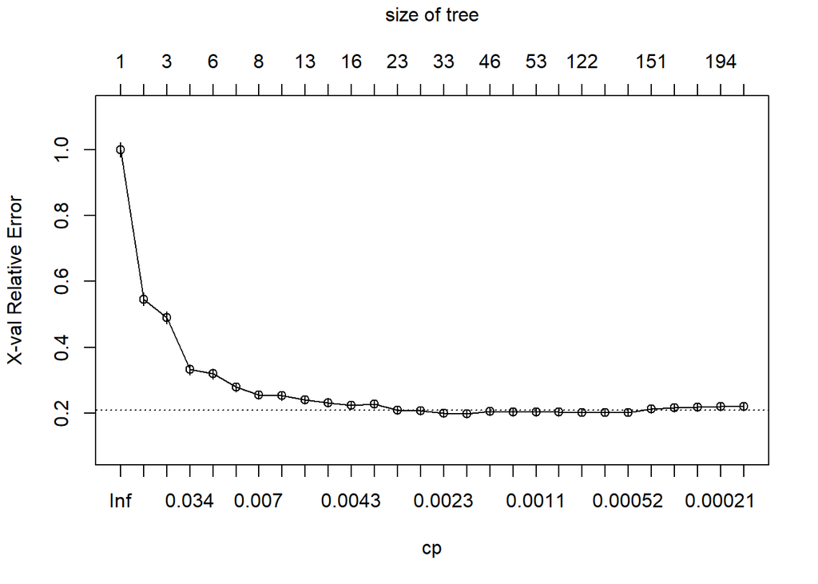

```r
plotcp(spambase_dt_model)
```

I grew the tree until the end as you can see in the x-val relative error - cp curve, aka learning curve. It shows a nice converging curve that indicates model is learning. Next step is to optimize the training model for to get maximum accuracy in testing phase.

```r
spambase_dt_model_opt <- rpart(X1 ~ .,
                               data = spambase_dt_training_data,
                               method="class",
                               control = rpart.control(minsplit= 1, cp = 0.0019))

spambase_dt_prediction <- predict(spambase_dt_model_opt, spambase_dt_test_data, type = "class")
spambase_dt_train_pred <- predict(spambase_dt_model_opt, spambase_dt_training_data, type = "class")

spambase_table_mat <- table(spambase_dt_test_data$X1, spambase_dt_prediction)
spambase_train_table_mat <- table(spambase_dt_training_data$X1, spambase_dt_train_pred)

spambase_dt_conf_mat <- confusionMatrix(factor(spambase_dt_prediction), factor(spambase_dt_test_data$X1))
spambase_dt_train_conf_mat <- confusionMatrix(factor(spambase_dt_train_pred), factor(spambase_dt_training_data$X1))


spambase_dt_prediction <- as.numeric(spambase_dt_prediction)
spambase_dt_train_pred <- as.numeric(spambase_dt_train_pred)

data.frame( R2   = R2(spambase_dt_prediction, spambase_dt_test_data$X1),
            RMSE = RMSE(spambase_dt_prediction, spambase_dt_test_data$X1),
            MAE  = MAE(spambase_dt_prediction, spambase_dt_test_data$X1),
            Train_Accuracy = sum(diag(spambase_train_table_mat)) / sum(spambase_train_table_mat),
            Test_Accuracy = sum(diag(spambase_table_mat)) / sum(spambase_table_mat))
```

```
##          R2     RMSE       MAE Train_Accuracy Test_Accuracy
## 1 0.6866921 1.024154 0.9837027       0.950424     0.9185137
```

```r
print(spambase_dt_train_conf_mat[["table"]])
```

```
##           Reference
## Prediction    0    1
##          0 1804   97
##          1   55 1110
```

```r
print(spambase_dt_conf_mat[["table"]])
```

```
##           Reference
## Prediction   0   1
##          0 879  75
##          1  50 530
```

```r
varImp(spambase_dt_model_opt)
```

```
##            Overall
## X0.1     10.741953
## X0.10     8.818118
## X0.11    28.317743
## X0.12    10.915628
## X0.13    19.883468
## X0.14     4.995122
## X0.15    19.769225
## X0.16   183.540266
## X0.17    80.246387
## X0.18    51.623001
## X0.21     9.589724
## X0.26    18.484241
## X0.27     2.450000
## X0.28    37.493825
## X0.3    597.072220
## X0.30    15.198891
## X0.32    81.581459
## X0.32.1 718.926195
## X0.34    21.685247
## X0.37    13.805878
## X0.38    30.537035
## X0.4     36.931834
## X0.41    10.153846
## X0.44   511.585058
## X0.5     13.281383
## X0.6      3.715875
## X0.64     3.114320
## X0.64.2  15.961916
## X0.7      7.650000
## X0.778  908.509000
## X0.8     15.915333
## X0.9     16.324239
## X0.96   592.309041
## X1.29     8.378213
## X1.93    16.842535
## X278     78.926361
## X3.756  256.618495
## X61      90.738050
## X0        0.000000
## X0.64.1   0.000000
## X0.2      0.000000
## X0.19     0.000000
## X0.20     0.000000
## X0.22     0.000000
## X0.23     0.000000
## X0.24     0.000000
## X0.25     0.000000
## X0.29     0.000000
## X0.31     0.000000
## X0.33     0.000000
## X0.35     0.000000
## X0.36     0.000000
## X0.39     0.000000
## X0.40     0.000000
## X0.42     0.000000
## X0.43     0.000000
## X0.45     0.000000
```

As it can be seen on the metrics, our model underfit as train accuracy outscores testing accuracy by %3 but in overall %92 is a high test accuracy.

### 3.3.2.Random Forest

As the name indicates, this appraoch is combined from several decision trees, like a “forest”. In theory, it is more suitable for nonlinear cases since more single trees might converge to more likely estimation for those scenarios.

- randomForest function used for modelling purposes with ntree = 500 and number = 10 as indicated in the report, more info can be seen on the printed OOB estimate of error rate.

```r
#Random Forest Approach

spambase_rf_training_data <- spambase_dt_training_data
spambase_rf_test_data <- spambase_dt_test_data


spambase_rf_training_data$X1 <- as.factor(spambase_rf_training_data$X1)
spambase_rf_test_data$X1 <- as.factor(spambase_rf_test_data$X1)


#RF Implement
#control <- trainControl(method = "cv", number = 20, search ="grid")

spambase_rf_model <- randomForest(X1~.,
                                  data = spambase_rf_training_data,
                                  ntree = 500,
                                  search = "grid",
                                  number = 10)


# Print the results
print(spambase_rf_model)
```

```
##
## Call:
##  randomForest(formula = X1 ~ ., data = spambase_rf_training_data,      ntree = 500, search = "grid", number = 10)
##                Type of random forest: classification
##                      Number of trees: 500
## No. of variables tried at each split: 7
##
##         OOB estimate of  error rate: 4.7%
## Confusion matrix:
##      0    1 class.error
## 0 1804   55  0.02958580
## 1   89 1118  0.07373654
```

OOB estimate of error rate is meaning that model is learning very nice in terms of accuracy, but before testing, model optimizing comes.

```r
spambase_rf_training_data_sub <- subset(spambase_rf_training_data, select = -c(X1))

floor(sqrt(ncol(spambase_rf_training_data) - 1))
```

```
## [1] 7
```

```
## mtry = 7  OOB error = 4.63%
## Searching left ...
## mtry = 4     OOB error = 4.79%
## -0.03521127 0.1
## Searching right ...
## mtry = 14    OOB error = 4.99%
## -0.07746479 0.1
```

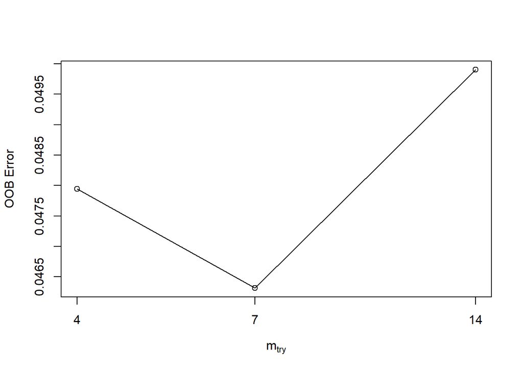

```r
spambase_mtry <- tuneRF(spambase_rf_training_data_sub,
                        spambase_rf_training_data$X1,
                        ntreeTry = 500,
                        stepFactor = 2,
                        improve = 0.1,
                        trace = TRUE,
                        plot = TRUE,
                        importance = TRUE)
```

```r
spambase_best.m <- spambase_mtry[spambase_mtry[, 2] == min(spambase_mtry[, 2]), 1]
print(spambase_mtry)
```

```
##        mtry   OOBError
## 4.OOB     4 0.04794521
## 7.OOB     7 0.04631442
## 14.OOB   14 0.04990215
```

```r
print(spambase_best.m)
```

```
## [1] 7
```

After tuning and taking the best parameters, test comes

```r
spambase_rf_optimal_model <-randomForest(X1~.,
                                         data = spambase_rf_training_data,
                                         mtry = spambase_best.m,
                                         ntree=500)

print(spambase_rf_optimal_model)
```

```
##
## Call:
##  randomForest(formula = X1 ~ ., data = spambase_rf_training_data,      mtry = spambase_best.m, ntree = 500)
##                Type of random forest: classification
##                      Number of trees: 500
## No. of variables tried at each split: 7
##
##         OOB estimate of  error rate: 4.7%
## Confusion matrix:
##      0    1 class.error
## 0 1806   53  0.02850995
## 1   91 1116  0.07539354
```

```r
#Evaluate variable importance
```

After evaluation , testing comes.

```r
spambase_rf_prediction <- predict(spambase_rf_optimal_model, newdata = spambase_rf_test_data, type = "class")
spambase_rf_training_prediction <- predict(spambase_rf_optimal_model, newdata = spambase_rf_training_data, type = "class")

spambase_rf_prediction <- as.numeric(spambase_rf_prediction)
spambase_rf_training_prediction <- as.numeric(spambase_rf_training_prediction)

spambase_rf_test_data$X1 <- as.numeric(spambase_rf_test_data$X1)
spambase_rf_training_data$X1 <- as.numeric(spambase_rf_training_data$X1)

spambase_rf_table_mat_test  <- table(spambase_rf_test_data$X1, spambase_rf_prediction)
spambase_rf_training_table_mat_test <- table(spambase_rf_training_data$X1, spambase_rf_training_prediction)

spambase_rf_test  <- confusionMatrix(factor(spambase_rf_prediction), factor(spambase_rf_test_data$X1))
spambase_rf_training <- confusionMatrix(factor(spambase_rf_training_prediction),factor(spambase_rf_training_data$X1))

data.frame( R2   = R2(spambase_rf_prediction, spambase_rf_test_data$X1),
            RMSE = RMSE(spambase_rf_prediction, spambase_rf_test_data$X1),
            MAE  = MAE(spambase_rf_prediction, spambase_rf_test_data$X1),
            Test_Acc = sum(diag(spambase_rf_training_table_mat_test)) / sum(spambase_rf_training_table_mat_test),
            Test_Acc = sum(diag(spambase_rf_table_mat_test)) / sum(spambase_rf_table_mat_test))
```

```
##          R2      RMSE        MAE  Test_Acc Test_Acc.1
## 1 0.7881599 0.2312034 0.05345502 0.9954338   0.946545
```

```r
print(spambase_rf_test[["table"]])
```

```
##           Reference
## Prediction   1   2
##          1 898  51
##          2  31 554
```

```r
print(spambase_rf_training[["table"]])
```

```
##           Reference
## Prediction    1    2
##          1 1859   14
##          2    0 1193
```

```r
varImp(spambase_rf_optimal_model)
```

```
##             Overall
## X0        4.9191835
## X0.64     5.8919802
## X0.64.1  13.7512346
## X0.1      1.5294016
## X0.32    42.3214481
## X0.2      9.6376031
## X0.3    101.7781240
## X0.4     20.3024676
## X0.5      5.0083698
## X0.6     13.6245663
## X0.7     16.1469095
## X0.64.2  15.7526652
## X0.8      4.6796383
## X0.9      4.2310195
## X0.10     1.8388781
## X0.32.1  86.0114589
## X0.11    19.0769765
## X1.29    11.7358766
## X1.93    37.9300497
## X0.12     7.2162543
## X0.96    82.2523584
## X0.13     5.9521128
## X0.14    35.8538945
## X0.15    55.4322148
## X0.16    63.4069955
## X0.17    26.6792286
## X0.18    23.0311447
## X0.19     8.4330535
## X0.20     3.1640388
## X0.21     7.1319978
## X0.22     2.7147416
## X0.23     1.0301865
## X0.24     3.7400984
## X0.25     0.8699964
## X0.26     6.6860158
## X0.27     5.7479001
## X0.28    19.5563563
## X0.29     0.6247649
## X0.30     4.7950686
## X0.31     1.5737219
## X0.33     1.0388346
## X0.34     8.7571394
## X0.35     2.3033896
## X0.36     2.6051462
## X0.37    12.1998964
## X0.38    24.5618880
## X0.39     0.3973135
## X0.40     1.6544677
## X0.41     7.8807267
## X0.42    17.0902094
## X0.43     4.0036932
## X0.778  187.3409507
## X0.44   143.1653703
## X0.45     5.9191904
## X3.756   95.4464006
## X61      78.7738301
## X278     59.2228983
```

Nearly perfect training score with high test accuracy, again slightly underfit.

## 3.4. Lasso Penalty

- glmnet and cv.glmnet used for the lasso penalty predictions.
- Target value changed to “yes” and “no” for in built function usage.
- Model trained and optimized for classification accuracy.

```r
spambase_lasso_training_data <- spambase_dt_training_data
spambase_lasso_test_data <- spambase_dt_test_data

for (i in 1:(nrow(spambase_lasso_training_data))) {

  if (spambase_lasso_training_data$X1[i] < 1) {

    spambase_lasso_training_data$X1[i] <- "no"

  } else {

    spambase_lasso_training_data$X1[i] <- "yes"
  }
}


# Make a custom trainControl - use ROC as a model selection criteria
spambase_control <- trainControl( method = "cv",
                                  number = 10,
                                  summaryFunction = twoClassSummary,
                                  classProbs = TRUE)

spambase_lasso_model <- train(X1~.,
                              spambase_lasso_training_data ,
                              method = "glmnet",
                              trControl = spambase_control)
#Check the model
spambase_lasso_model
```

```
## glmnet
##
## 3066 samples
##   57 predictor
##    2 classes: 'no', 'yes'
##
## No pre-processing
## Resampling: Cross-Validated (10 fold)
## Summary of sample sizes: 2759, 2759, 2759, 2759, 2759, 2760, ...
## Resampling results across tuning parameters:
##
##   alpha  lambda        ROC        Sens       Spec
##   0.10   0.0003850258  0.9703625  0.9510607  0.8823416
##   0.10   0.0038502575  0.9692006  0.9521331  0.8715840
##   0.10   0.0385025751  0.9606632  0.9580529  0.8309780
##   0.55   0.0003850258  0.9706795  0.9510607  0.8840014
##   0.55   0.0038502575  0.9690942  0.9548242  0.8657920
##   0.55   0.0385025751  0.9553264  0.9639698  0.7547865
##   1.00   0.0003850258  0.9708062  0.9499855  0.8856612
##   1.00   0.0038502575  0.9689032  0.9553618  0.8641322
##   1.00   0.0385025751  0.9460954  0.9650480  0.6884986
##
## ROC was used to select the optimal model using the largest value.
## The final values used for the model were alpha = 1 and lambda = 0.0003850258.
```

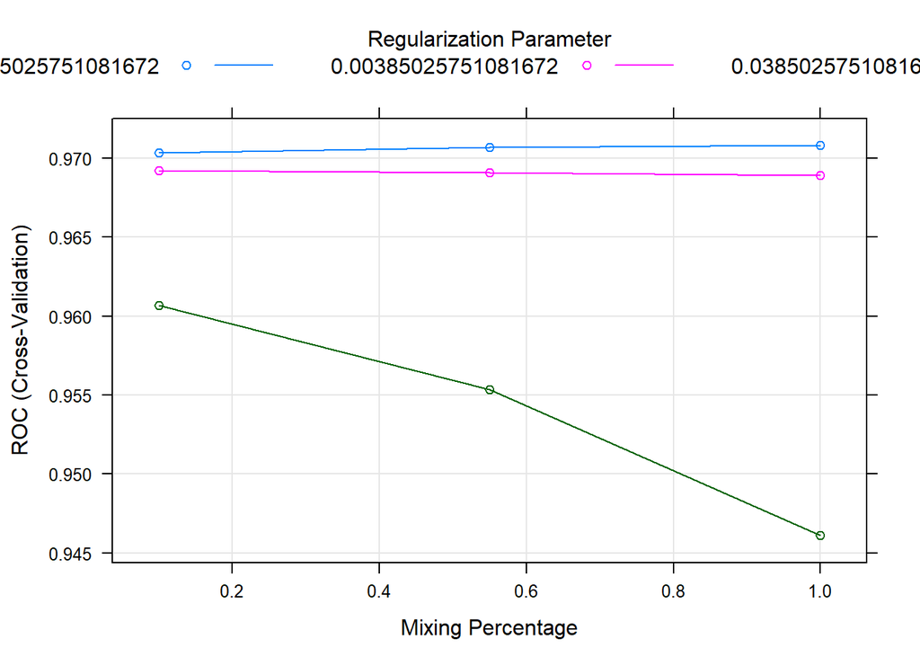

```r
plot(spambase_lasso_model)
```

```r
max(spambase_lasso_model[["results"]]$ROC)
```

```
## [1] 0.9708062
```

From these results, model will now testing:

```r
spambase_lasso_prediction <- predict(spambase_lasso_model, spambase_lasso_test_data, type.measure = "class")
spambase_lasso_training_prediction <- predict(spambase_lasso_model, spambase_lasso_training_data, type.measure = "class")

spambase_lasso_prediction <- as.numeric(spambase_lasso_prediction)
spambase_lasso_training_prediction <- as.numeric(spambase_lasso_training_prediction)

spambase_lasso_table_mat <- table(spambase_lasso_test_data$X1, spambase_lasso_prediction)
spambase_lasso_training_table_mat <- table(spambase_lasso_training_data$X1, spambase_lasso_training_prediction)

spambase_lasso_conf_mat <- confusionMatrix(factor(spambase_lasso_prediction), factor(spambase_rf_test_data$X1))
spambase_lasso_training_conf_mat <- confusionMatrix(factor(spambase_lasso_training_prediction), factor(spambase_rf_training_data$X1))



data.frame( R2 = R2(spambase_lasso_prediction, spambase_rf_test_data$X1),
            RMSE = RMSE(spambase_lasso_prediction, spambase_rf_test_data$X1),
            MAE  = MAE(spambase_lasso_prediction, spambase_rf_test_data$X1),
            Training_Accuracy = sum(diag(spambase_lasso_training_table_mat)) / sum(spambase_lasso_training_table_mat),
            Test_Accuracy = sum(diag(spambase_lasso_table_mat)) / sum(spambase_lasso_table_mat))
```

```
##          R2      RMSE        MAE Training_Accuracy Test_Accuracy
## 1 0.7051651 0.2761724 0.07627119         0.9324853     0.9237288
```

```r
print(spambase_lasso_conf_mat[["table"]])
```

```
##           Reference
## Prediction   1   2
##          1 880  68
##          2  49 537
```

```r
print(spambase_lasso_conf_mat[["table"]])
```

```
##           Reference
## Prediction   1   2
##          1 880  68
##          2  49 537
```

```r
varImp(spambase_lasso_model)
```

```
## glmnet variable importance
##
##   only 20 most important variables shown (out of 57)
##
##         Overall
## X0.44    100.00
## X0.33     89.33
## X0.40     71.99
## X0.14     69.20
## X0.26     65.59
## X0.22     56.66
## X0.39     48.82
## X0.45     47.41
## X0.18     44.73
## X0.20     43.20
## X0.34     38.88
## X0.10     33.17
## X0.3      32.96
## X0.16     31.29
## X0.38     24.99
## X0.17     23.81
## X0.41     22.50
## X0.36     22.41
## X0.32.1   19.19
## X0.35     17.57
```

This time model did not underfit, but scored slightly lower than training which is the must case in order to avoid overfitting.

## 3.5.SGD

Again in this block, this followed:

```r
library(xgboost)

spambase_sgd_training_data <- spambase_dt_training_data
spambase_sgd_test_data <- spambase_dt_test_data

spambase_sgd_training_data$X1 <- as.factor(spambase_sgd_training_data$X1)
spambase_sgd_test_data$X1 <- as.factor(spambase_sgd_test_data$X1)

spambase_sgd_model <- train(X1~.,
                            data = spambase_sgd_training_data,
                            method = "xgbTree",
                            trControl = trainControl("cv", number = 10))
spambase_sgd_model
```

```
## eXtreme Gradient Boosting
##
## 3066 samples
##   57 predictor
##    2 classes: '0', '1'
##
## No pre-processing
## Resampling: Cross-Validated (10 fold)
## Summary of sample sizes: 2760, 2760, 2759, 2759, 2760, 2759, ...
## Resampling results across tuning parameters:
##
##   eta  max_depth  colsample_bytree  subsample  nrounds  Accuracy   Kappa
##   0.3  1          0.6               0.50        50      0.9341221  0.8606561
##   0.3  1          0.6               0.50       100      0.9413000  0.8763064
##   0.3  1          0.6               0.50       150      0.9452087  0.8845332
##   0.3  1          0.6               0.75        50      0.9350951  0.8627447
##   0.3  1          0.6               0.75       100      0.9435801  0.8811052
##   0.3  1          0.6               0.75       150      0.9455355  0.8853423
##   0.3  1          0.6               1.00        50      0.9364044  0.8653310
##   0.3  1          0.6               1.00       100      0.9412968  0.8761363
##   0.3  1          0.6               1.00       150      0.9465127  0.8873927
##   0.3  1          0.8               0.50        50      0.9347757  0.8619722
##   0.3  1          0.8               0.50       100      0.9429307  0.8796699
##   0.3  1          0.8               0.50       150      0.9455334  0.8852178
##   0.3  1          0.8               0.75        50      0.9377137  0.8684401
##   0.3  1          0.8               0.75       100      0.9435822  0.8810977
##   0.3  1          0.8               0.75       150      0.9468406  0.8880553
##   0.3  1          0.8               1.00        50      0.9370612  0.8667995
##   0.3  1          0.8               1.00       100      0.9426008  0.8789914
##   0.3  1          0.8               1.00       150      0.9484703  0.8914882
##   0.3  2          0.6               0.50        50      0.9396670  0.8727623
##   0.3  2          0.6               0.50       100      0.9461870  0.8868772
##   0.3  2          0.6               0.50       150      0.9474921  0.8896102
##   0.3  2          0.6               0.75        50      0.9452109  0.8846257
##   0.3  2          0.6               0.75       100      0.9461913  0.8867851
##   0.3  2          0.6               0.75       150      0.9474942  0.8895697
##   0.3  2          0.6               1.00        50      0.9468427  0.8879335
##   0.3  2          0.6               1.00       100      0.9491239  0.8928671
##   0.3  2          0.6               1.00       150      0.9507526  0.8963874
##   0.3  2          0.8               0.50        50      0.9432533  0.8803144
```

[output cut: 73 more lines]

```
##   0.4  3          0.8               0.50       150      0.9491197  0.8931605
##   0.4  3          0.8               0.75        50      0.9455355  0.8854273
##   0.4  3          0.8               0.75       100      0.9471631  0.8891916
##   0.4  3          0.8               0.75       150      0.9458581  0.8864986
##   0.4  3          0.8               1.00        50      0.9487950  0.8924414
##   0.4  3          0.8               1.00       100      0.9484714  0.8919530
##   0.4  3          0.8               1.00       150      0.9481467  0.8911385
##
## Tuning parameter 'gamma' was held constant at a value of 0
## Tuning
##  parameter 'min_child_weight' was held constant at a value of 1
## Accuracy was used to select the optimal model using the largest value.
## The final values used for the model were nrounds = 100, max_depth = 3, eta
##  = 0.4, gamma = 0, colsample_bytree = 0.6, min_child_weight = 1 and subsample
##  = 1.
```

```r
spambase_sgd_model$bestTune
```

```
##    nrounds max_depth eta gamma colsample_bytree min_child_weight subsample
## 98     100         3 0.4     0              0.6                1         1
```

Moving to testing after tuning:

```r
spambase_sgd_prediction <- spambase_sgd_model %>% predict(spambase_rf_test_data)
spambase_sgd_training_prediction <- spambase_sgd_model %>% predict(spambase_rf_training_data)

spambase_sgd_prediction <- as.numeric(spambase_sgd_prediction)
spambase_sgd_training_prediction <- as.numeric(spambase_sgd_training_prediction)

spambase_sgd_table_mat <- table(spambase_sgd_test_data$X1, spambase_sgd_prediction)
spambase_sgd_training_table_mat <- table(spambase_sgd_training_data$X1, spambase_sgd_training_prediction)

spambase_sgd_conf_mat <- confusionMatrix(factor(spambase_sgd_prediction), factor(spambase_rf_test_data$X1))
spambase_sgd_training_conf_mat <- confusionMatrix(factor(spambase_sgd_training_prediction), factor(spambase_rf_training_data$X1))

data.frame( R2 = R2(spambase_sgd_prediction, spambase_rf_test_data$X1),
            RMSE = RMSE(spambase_sgd_prediction, spambase_rf_test_data$X1),
            MAE  = MAE(spambase_sgd_prediction, spambase_rf_test_data$X1),
            Training_Accuracy = sum(diag(spambase_sgd_training_table_mat)) / sum(spambase_sgd_training_table_mat),
            Test_Accuracy = sum(diag(spambase_sgd_table_mat)) / sum(spambase_sgd_table_mat))
```

```
##          R2      RMSE       MAE Training_Accuracy Test_Accuracy
## 1 0.8079682 0.2196358 0.0482399         0.9885845     0.9517601
```

```r
print(spambase_sgd_conf_mat[["table"]])
```

```
##           Reference
## Prediction   1   2
##          1 895  40
##          2  34 565
```

```r
print(spambase_sgd_training_conf_mat[["table"]])
```

```
##           Reference
## Prediction    1    2
##          1 1848   24
##          2   11 1183
```

```r
varImp(spambase_sgd_model)
```

```
## xgbTree variable importance
##
##   only 20 most important variables shown (out of 57)
##
##         Overall
## X0.3    100.000
## X0.778   86.113
## X0.15    51.396
## X0.16    44.650
## X0.44    34.329
## X3.756   31.393
## X0.32.1  30.695
## X0.18    24.620
## X0.38    22.319
## X278     19.345
## X0.96    17.207
## X61      15.957
## X0.14    15.791
## X0.32    10.322
## X0.34     7.110
## X1.93     6.837
## X0.28     6.506
## X0.64.2   5.744
## X0.11     5.688
## X0.37     5.123
```

Nearly perfect training accuracy followed by slightly less testing accuracy is showing that model has learned almost perfectly without overfitting.

# **4.Mice Protein Expression Data Set**

## 4.1.Libraries

Same Libraries will be used for all reports.

## 4.2.Data Import

```r
mice_data <- readxl::read_xls("Data_Cortex_Nuclear.xls")

# creating a backup dataset for usage purposes, after cleaning missing values, also first column ID will be extracted with genotype, treatment, behavior since they are the main subclasses of the target class

mice_data2 <- na.omit(mice_data)

mice_data2$MouseID <- NULL
mice_data2$Genotype <- NULL
mice_data2$Treatment <- NULL
mice_data2$Behavior <- NULL

# one more backup file for comparison possible comparison

mice_data3 <- mice_data2

# also class will be changed to numeric for handiness

mice_data2$class <- as.numeric(as.factor(mice_data2$class))
```

## 4.3.Tree Based Approaches

### 4.3.1.CART

[figure not shown]

```r
# Classification Tree with rpart

## 75% of the sample size
mice_smp_size <- floor((2/3) * nrow(mice_data2))

## set the seed to make your partition reproducible
set.seed(123)

mice_train_ind <- sample(seq_len(nrow(mice_data2)), size = mice_smp_size)

mice_dt_training_data <- mice_data2[ mice_train_ind, ]
mice_dt_test_data <- mice_data2[-mice_train_ind, ]

mice_dt_model <- rpart(class ~ .,
                       data = mice_dt_training_data,
                       method = "class",
                       control = rpart.control(minsplit= 1, cp = 0.001))

#Plot Decision Tree
rpart.plot(mice_dt_model)
```

```r
# Examine the complexity plot
printcp(mice_dt_model)
```

```
##
## Classification tree:
## rpart(formula = class ~ ., data = mice_dt_training_data, method = "class",
##     control = rpart.control(minsplit = 1, cp = 0.001))
##
## Variables actually used in tree construction:
##  [1] ADARB1_N  AKT_N     ARC_N     BDNF_N    BRAF_N    DYRK1A_N  ITSN1_N
##  [8] MTOR_N    NR2A_N    P38_N     pAKT_N    pCAMKII_N pCASP9_N  pMEK_N
## [15] pNR1_N    pP70S6_N  pPKCG_N   RRP1_N    SHH_N     SNCA_N    SOD1_N
## [22] Tau_N
##
## Root node error: 303/368 = 0.82337
##
## n= 368
##
##           CP nsplit rel error  xerror     xstd
## 1  0.1584158      0  1.000000 1.00000 0.024144
## 2  0.1320132      1  0.841584 0.84158 0.029204
## 3  0.1287129      2  0.709571 0.74587 0.030820
## 4  0.1155116      3  0.580858 0.64686 0.031588
## 5  0.0990099      4  0.465347 0.55116 0.031520
## 6  0.0297030      6  0.267327 0.37294 0.029204
## 7  0.0264026      9  0.178218 0.33663 0.028338
## 8  0.0231023     10  0.151815 0.30033 0.027315
## 9  0.0132013     11  0.128713 0.28383 0.026792
## 10 0.0099010     12  0.115512 0.26733 0.026231
## 11 0.0066007     16  0.075908 0.24092 0.025247
## 12 0.0033003     22  0.036304 0.22112 0.024432
## 13 0.0010000     33  0.000000 0.20132 0.023543
```

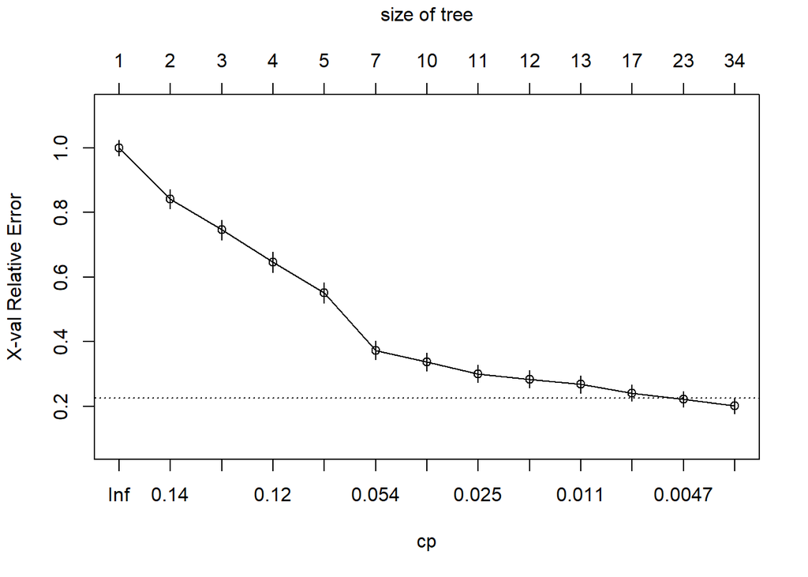

```r
plotcp(mice_dt_model)
```

Learning curve is converged very nicely, indicating a good learning. Model optimizing and prediction :

```r
mice_dt_model_opt <- rpart(class ~ .,
                           data = mice_dt_training_data,
                           method = "class",
                           control = rpart.control(minsplit= 1, cp = 0.006))

mice_dt_prediction <- predict(mice_dt_model_opt, mice_dt_test_data, type = "class")
mice_dt_training_prediction <- predict(mice_dt_model_opt, mice_dt_training_data, type = "class")

mice_table_mat <- table(mice_dt_test_data$class, mice_dt_prediction)
mice_training_table_mat <- table(mice_dt_training_data$class, mice_dt_training_prediction)

mice_dt_conf_mat <- confusionMatrix(factor(mice_dt_prediction), factor(mice_dt_test_data$class))
mice_dt_training_conf_mat <- confusionMatrix(factor(mice_dt_training_prediction), factor(mice_dt_training_data$class))

mice_dt_prediction <- as.numeric(mice_dt_prediction)
mice_dt_training_prediction <- as.numeric(mice_dt_training_prediction)

data.frame( R2   = R2(mice_dt_prediction, mice_dt_test_data$class),
            RMSE = RMSE(mice_dt_prediction, mice_dt_test_data$class),
            MAE  = MAE(mice_dt_prediction, mice_dt_test_data$class),
            MAPE = MAPE(mice_dt_prediction, mice_dt_test_data$class),
            Training_Accuracy = sum(diag(mice_training_table_mat)) / sum(mice_training_table_mat),
            Test_Accuracy = sum(diag(mice_table_mat)) / sum(mice_table_mat))
```

```
##          R2     RMSE       MAE      MAPE Training_Accuracy Test_Accuracy
## 1 0.7385559 1.204611 0.3641304 0.1443841         0.9701087     0.8641304
```

```r
print(mice_dt_conf_mat[["table"]])
```

```
##           Reference
## Prediction  1  2  3  4  5  6  7  8
##          1 14  4  0  0  1  0  0  2
##          2  0 14  0  0  1  3  0  0
##          3  0  0 19  5  0  0  0  0
##          4  0  0  1 22  0  0  0  0
##          5  2  3  0  0 23  2  0  0
##          6  1  0  0  0  0 20  0  0
##          7  0  0  0  0  0  0 18  0
##          8  0  0  0  0  0  0  0 29
```

```r
print(mice_dt_training_conf_mat[["table"]])
```

```
##           Reference
## Prediction  1  2  3  4  5  6  7  8
##          1 26  1  1  0  1  0  0  1
##          2  1 51  0  0  0  1  0  0
##          3  0  0 39  0  0  0  1  0
##          4  0  0  0 48  0  0  0  0
##          5  1  0  0  0 64  1  0  0
##          6  0  2  0  0  0 48  0  0
##          7  0  0  0  0  0  0 41  0
##          8  0  0  0  0  0  0  0 40
```

```r
varImp(mice_dt_model_opt)
```

```
##                   Overall
## AcetylH3K9_N    43.202831
## ADARB1_N        14.041517
## AKT_N           64.749157
## AMPKA_N          2.450583
## APP_N           45.164618
## ARC_N           65.291345
## BAX_N           11.971930
## BDNF_N           5.456410
## BRAF_N          89.925364
## CAMKII_N        20.669206
## CaNA_N          16.635305
## DYRK1A_N        36.080609
## ERBB4_N         10.289385
## GFAP_N           8.427469
## GluR3_N          9.212740
## GSK3B_N          4.714286
## ITSN1_N         28.601141
## JNK_N           10.024302
## MTOR_N          10.289385
## NR1_N            1.866667
## NR2A_N           5.649857
## NUMB_N           7.324857
## P3525_N          8.338895
## P38_N           65.356301
## pBRAF_N          5.456410
## pCAMKII_N       64.797875
## pCASP9_N         6.432653
## pCFOS_N         12.431756
## pCREB_N          6.589744
## pERK_N          37.953689
## pGSK3B_N        32.268347
## pGSK3B_Tyr216_N 21.633331
## pJNK_N          15.075198
## pMEK_N           5.483346
## pNR2A_N          3.818182
## pNUMB_N         34.283667
## pP70S6_N        24.329252
## pPKCAB_N        10.972594
## pPKCG_N         44.605302
```

[output cut: 23 more lines]

```
## NR2B_N           0.000000
## TIAM1_N          0.000000
## P70S6_N          0.000000
## CDK5_N           0.000000
## S6_N             0.000000
## nNOS_N           0.000000
## GluR4_N          0.000000
## IL1B_N           0.000000
## Ubiquitin_N      0.000000
## BAD_N            0.000000
## BCL2_N           0.000000
## SYP_N            0.000000
## H3AcK18_N        0.000000
## EGR1_N           0.000000
## H3MeK4_N         0.000000
```

Some serious underfitting occurred but regardless of a nearly perfect train acc. , testing accuracy is quite high with over %85.

### 4.3.2.Random Forest

```r
#Random Forest Approach

mice_rf_training_data <- mice_dt_training_data
mice_rf_test_data <- mice_dt_test_data


mice_rf_training_data$class <- as.factor(mice_rf_training_data$class)
mice_rf_test_data$class <- as.factor(mice_rf_test_data$class)


#RF Implement

mice_rf_model <- randomForest(class~.,
                              data = mice_rf_training_data,
                              ntree = 500,
                              method = "class",
                              search = "grid",
                              number = 10)

# Print the results
print(mice_rf_model)
```

```
##
## Call:
##  randomForest(formula = class ~ ., data = mice_rf_training_data,      ntree = 500, method = "class", search = "grid", number = 10)
##                Type of random forest: classification
##                      Number of trees: 500
## No. of variables tried at each split: 8
##
##         OOB estimate of  error rate: 1.63%
## Confusion matrix:
##    1  2  3  4  5  6  7  8 class.error
## 1 26  0  0  0  1  1  0  0  0.07142857
## 2  0 52  0  0  2  0  0  0  0.03703704
## 3  0  0 40  0  0  0  0  0  0.00000000
## 4  0  0  0 48  0  0  0  0  0.00000000
## 5  0  1  0  0 64  0  0  0  0.01538462
## 6  0  0  0  0  0 50  0  0  0.00000000
## 7  0  0  1  0  0  0 41  0  0.02380952
## 8  0  0  0  0  0  0  0 41  0.00000000
```

Nearly perfect training, might be overfitted. Will be understand after testing accuracy. Again parameter tuning, selecting the best parameters to optimize the teset accuracy.

```r
mice_rf_training_data_sub <- subset(mice_rf_training_data, select = -c(class))

floor(sqrt(ncol(mice_rf_training_data) - 1))
```

```
## [1] 8
```

```
## mtry = 8  OOB error = 2.17%
## Searching left ...
## mtry = 4     OOB error = 2.17%
## 0 0.03
## Searching right ...
## mtry = 16    OOB error = 2.17%
## 0 0.03
```

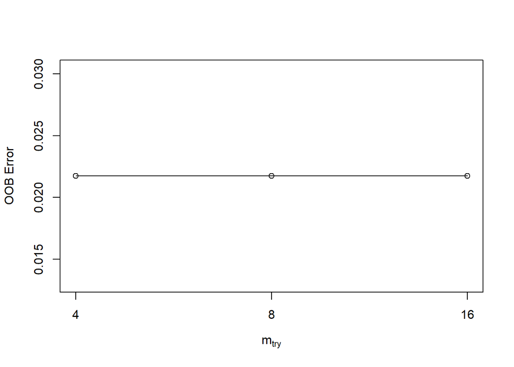

```r
mice_mtry <- tuneRF(mice_rf_training_data_sub,
                    mice_rf_training_data$class,
                    ntreeTry = 500,
                    stepFactor = 2,
                    improve = 0.03,
                    trace = TRUE,
                    plot = TRUE,
                    importance = TRUE)
```

```r
mice_best.m <- mice_mtry[mice_mtry[, 2] == min(mice_mtry[, 2]), 1]
print(mice_mtry)
```

```
##        mtry   OOBError
## 4.OOB     4 0.02173913
## 8.OOB     8 0.02173913
## 16.OOB   16 0.02173913
```

```r
print(mice_best.m)
```

```
##  4.OOB  8.OOB 16.OOB
##      4      8     16
```

```r
mice_rf_optimal_model <-randomForest(class~.,
                                     data = mice_rf_training_data,
                                     mtry = mice_best.m,
                                     ntree=500)

print(mice_rf_optimal_model)
```

```
##
## Call:
##  randomForest(formula = class ~ ., data = mice_rf_training_data,      mtry = mice_best.m, ntree = 500)
##                Type of random forest: classification
##                      Number of trees: 500
## No. of variables tried at each split: 4
##
##         OOB estimate of  error rate: 1.36%
## Confusion matrix:
##    1  2  3  4  5  6  7  8 class.error
## 1 26  1  0  0  1  0  0  0  0.07142857
## 2  0 54  0  0  0  0  0  0  0.00000000
## 3  0  0 40  0  0  0  0  0  0.00000000
## 4  0  0  0 48  0  0  0  0  0.00000000
## 5  0  1  0  0 64  0  0  0  0.01538462
## 6  0  0  0  0  1 49  0  0  0.02000000
## 7  0  0  1  0  0  0 41  0  0.02380952
## 8  0  0  0  0  0  0  0 41  0.00000000
```

```r
#Evaluate variable importance
```

Model evaluated and can be seen through OOB rate and confusion matrix:

```r
mice_rf_test_prediction <- predict(mice_rf_optimal_model, newdata = mice_rf_test_data, type = "class")
mice_rf_training_prediction <- predict(mice_rf_optimal_model, newdata = mice_rf_training_data, type = "class")

mice_rf_test_prediction <- as.numeric(mice_rf_test_prediction)
mice_rf_training_prediction <- as.numeric(mice_rf_training_prediction)

mice_rf_test_data$class <- as.numeric(mice_rf_test_data$class)

mice_rf_table_mat_test  <- table(mice_rf_test_data$class, mice_rf_test_prediction)
mice_rf_table_mat_training <- table(mice_rf_training_data$class, mice_rf_training_prediction)

#mice_rf_test  <- confusionMatrix(factor(mice_rf_test_prediction), factor(mice_rf_test_data$class))
#mice_rf_train <- confusionMatrix(factor(predict(mice_rf_optimal_model, mice_rf_training_data, type="class")), factor(mice_rf_training_data$class))

mice_rf_conf_mat_test <- confusionMatrix(factor(mice_rf_test_prediction), factor(mice_rf_test_data$class))
mice_rf_conf_mat_training <- confusionMatrix(factor(mice_rf_training_prediction), factor(mice_rf_training_data$class))


data.frame( R2   = R2(mice_rf_test_prediction, mice_rf_test_data$class),
            RMSE = RMSE(mice_rf_test_prediction, mice_rf_test_data$class),
            MAE  = MAE(mice_rf_test_prediction, mice_rf_test_data$class),
            Training_Acc = sum(diag(mice_rf_table_mat_training)) / sum(mice_rf_table_mat_training),
            Test_Acc = sum(diag(mice_rf_table_mat_test)) / sum(mice_rf_table_mat_test))
```

```
##          R2      RMSE        MAE Training_Acc  Test_Acc
## 1 0.9829538 0.2948839 0.02173913            1 0.9945652
```

```r
print(mice_rf_conf_mat_training[["table"]])
```

```
##           Reference
## Prediction  1  2  3  4  5  6  7  8
##          1 28  0  0  0  0  0  0  0
##          2  0 54  0  0  0  0  0  0
##          3  0  0 40  0  0  0  0  0
##          4  0  0  0 48  0  0  0  0
##          5  0  0  0  0 65  0  0  0
##          6  0  0  0  0  0 50  0  0
##          7  0  0  0  0  0  0 42  0
##          8  0  0  0  0  0  0  0 41
```

```r
print(mice_rf_conf_mat_test[["table"]])
```

```
##           Reference
## Prediction  1  2  3  4  5  6  7  8
##          1 16  0  0  0  0  0  0  0
##          2  0 21  0  0  0  0  0  0
##          3  0  0 20  0  0  0  0  0
##          4  0  0  0 27  0  0  0  0
##          5  1  0  0  0 25  0  0  0
##          6  0  0  0  0  0 25  0  0
##          7  0  0  0  0  0  0 18  0
##          8  0  0  0  0  0  0  0 31
```

```r
varImp(mice_rf_optimal_model)
```

```
##                   Overall
## DYRK1A_N         8.690641
## ITSN1_N          6.621523
## BDNF_N           1.846961
## NR1_N            2.325204
## NR2A_N           1.878595
## pAKT_N           3.012486
## pBRAF_N          2.024736
## pCAMKII_N        6.750514
## pCREB_N          2.680172
## pELK_N           4.486939
## pERK_N           9.479501
## pJNK_N           2.497991
## PKCA_N           3.348945
## pMEK_N           2.578401
## pNR1_N           2.343368
## pNR2A_N          2.776764
## pNR2B_N          1.895587
## pPKCAB_N         6.363003
## pRSK_N           3.233114
## AKT_N            6.621955
## BRAF_N          11.801684
## CAMKII_N         2.840018
## CREB_N           2.295178
## ELK_N            1.797632
## ERK_N            2.278617
## GSK3B_N          3.744935
## JNK_N            2.531750
## MEK_N            1.933438
## TRKA_N           1.989279
## RSK_N            2.463554
## APP_N            5.302736
## Bcatenin_N       1.400078
## SOD1_N          13.140563
## MTOR_N           2.766347
## P38_N            6.572254
## pMTOR_N          3.700516
## DSCR1_N          3.600772
## AMPKA_N          2.986421
## NR2B_N           3.513071
```

[output cut: 23 more lines]

```
## pCASP9_N         3.594582
## PSD95_N          2.979095
## SNCA_N           3.420063
## Ubiquitin_N      6.362591
## pGSK3B_Tyr216_N  4.030293
## SHH_N            3.173202
## BAD_N            2.096017
## BCL2_N           2.434426
## pS6_N            7.624952
## pCFOS_N          2.550972
## SYP_N            2.683996
## H3AcK18_N        4.158434
## EGR1_N           2.056375
## H3MeK4_N         2.615271
## CaNA_N           8.064331
```

## 4.4.Lasso Penalty

- cv.glmnet used with multinomial to classify multiple classes.

```r
library(glmnet)

mice_lasso_training_data <- mice_dt_training_data
mice_lasso_test_data <- mice_dt_test_data

mice_lasso_model <- cv.glmnet(x = as.matrix(mice_lasso_training_data%>%select(-class)),
                              y = as.factor(mice_lasso_training_data$class),
                              family = "multinomial",
                              type.measure = c("class"),
                              nfolds = 5,
                              alpha = 1)

#Check the model
mice_lasso_model
```

```
##
## Call:  cv.glmnet(x = as.matrix(mice_lasso_training_data %>% select(-class)),      y = as.factor(mice_lasso_training_data$class), type.measure = c("class"),      nfolds = 5, family = "multinomial", alpha = 1)
##
## Measure: Misclassification Error
##
##       Lambda Measure       SE Nonzero
## min 0.004959 0.01359 0.006091      13
## 1se 0.007896 0.01902 0.006919      11
```

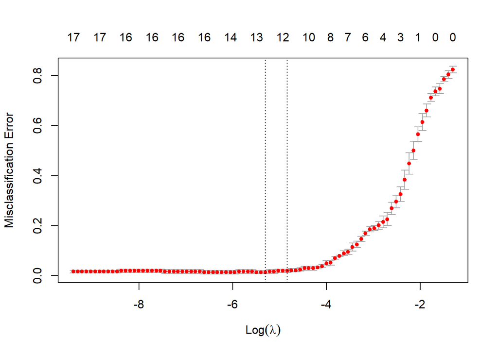

```r
plot(mice_lasso_model)
```

Error curve converges perfectly for shown log values :

```r
mice_lasso_test_prediction <- predict(mice_lasso_model, newx=as.matrix(mice_lasso_test_data%>%select(-class)), s=c("lambda.min"),type="class")[,1]
mice_lasso_training_prediction <- predict(mice_lasso_model, newx=as.matrix(mice_lasso_training_data%>%select(-class)), s=c("lambda.min"),type="class")[,1]

mice_lasso_training_pred <- as.numeric(mice_lasso_training_prediction)
mice_lasso_test_prediction <- as.numeric(mice_lasso_test_prediction)

mice_lasso_test_table_mat <- table(mice_lasso_test_data$class, mice_lasso_test_prediction)
mice_lasso_training_table_mat <- table(mice_lasso_training_data$class, mice_lasso_training_prediction)

mice_lasso_test_conf_mat <- confusionMatrix(factor(mice_lasso_test_prediction), factor(mice_rf_test_data$class))
mice_lasso_training_conf_mat <- confusionMatrix(factor(mice_lasso_training_prediction), factor(mice_rf_training_data$class))

data.frame( R2 = R2(mice_lasso_test_prediction, mice_rf_test_data$class),
            RMSE = RMSE(mice_lasso_test_prediction, mice_rf_test_data$class),
            MAE  = MAE(mice_lasso_test_prediction, mice_rf_test_data$class),
            Training_Accuracy = sum(diag(mice_lasso_training_table_mat)) / sum(mice_lasso_training_table_mat),
            Test_Accuracy = sum(diag(mice_lasso_test_table_mat)) / sum(mice_lasso_test_table_mat))
```

```
##   R2 RMSE MAE Training_Accuracy Test_Accuracy
## 1  1    0   0                 1             1
```

```r
print(mice_lasso_training_conf_mat[["table"]])
```

```
##           Reference
## Prediction  1  2  3  4  5  6  7  8
##          1 28  0  0  0  0  0  0  0
##          2  0 54  0  0  0  0  0  0
##          3  0  0 40  0  0  0  0  0
##          4  0  0  0 48  0  0  0  0
##          5  0  0  0  0 65  0  0  0
##          6  0  0  0  0  0 50  0  0
##          7  0  0  0  0  0  0 42  0
##          8  0  0  0  0  0  0  0 41
```

```r
print(mice_lasso_test_conf_mat[["table"]])
```

```
##           Reference
## Prediction  1  2  3  4  5  6  7  8
##          1 17  0  0  0  0  0  0  0
##          2  0 21  0  0  0  0  0  0
##          3  0  0 20  0  0  0  0  0
##          4  0  0  0 27  0  0  0  0
##          5  0  0  0  0 25  0  0  0
##          6  0  0  0  0  0 25  0  0
##          7  0  0  0  0  0  0 18  0
##          8  0  0  0  0  0  0  0 31
```

This time both training and testing score’s are perfect. Other result where suspicious but were acceptable since testing accuracy was outscored by training accuracy, but both of them scoring perfect score seems kinda memorization, not learning.

- xgbTree Used for modelling and the model tuned.

```r
library(xgboost)

mice_sgd_training_data <- mice_dt_training_data
mice_sgd_test_data <- mice_dt_test_data

mice_sgd_training_data$class <- as.factor(mice_sgd_training_data$class)
mice_sgd_test_data$class <- as.factor(mice_sgd_test_data$class)

mice_sgd_model <- train(class~.,
                        data = mice_sgd_training_data,
                        method = "xgbTree",
                        trControl = trainControl("cv", number = 10))

mice_sgd_model$bestTune
```

```
##    nrounds max_depth eta gamma colsample_bytree min_child_weight subsample
## 68     100         1 0.4     0              0.8                1      0.75
```

```r
mice_sgd_prediction <- mice_sgd_model %>% predict(mice_rf_test_data)
mice_sgd_prediction <- as.numeric(mice_sgd_prediction)

mice_sgd_table_mat <- table(mice_sgd_test_data$class, mice_sgd_prediction)

mice_sgd_conf_mat <- confusionMatrix(factor(mice_sgd_prediction), factor(mice_rf_test_data$class))

mice_lasso_test_table_mat <- table(mice_lasso_test_data$class, mice_lasso_test_prediction)
mice_lasso_training_table_mat <- table(mice_lasso_training_data$class, mice_lasso_training_prediction)

mice_lasso_test_conf_mat <- confusionMatrix(factor(mice_lasso_test_prediction), factor(mice_rf_test_data$class))
mice_lasso_training_conf_mat <- confusionMatrix(factor(mice_lasso_training_prediction), factor(mice_rf_training_data$class))

data.frame( R2 = R2(mice_lasso_test_prediction, mice_rf_test_data$class),
            RMSE = RMSE(mice_lasso_test_prediction, mice_rf_test_data$class),
            MAE  = MAE(mice_lasso_test_prediction, mice_rf_test_data$class),
            Training_Accuracy = sum(diag(mice_lasso_training_table_mat)) / sum(mice_lasso_training_table_mat),
            Test_Accuracy = sum(diag(mice_lasso_test_table_mat)) / sum(mice_lasso_test_table_mat))
```

```
##   R2 RMSE MAE Training_Accuracy Test_Accuracy
## 1  1    0   0                 1             1
```

```r
print(mice_lasso_training_conf_mat[["table"]])
```

```
##           Reference
## Prediction  1  2  3  4  5  6  7  8
##          1 28  0  0  0  0  0  0  0
##          2  0 54  0  0  0  0  0  0
##          3  0  0 40  0  0  0  0  0
##          4  0  0  0 48  0  0  0  0
##          5  0  0  0  0 65  0  0  0
##          6  0  0  0  0  0 50  0  0
##          7  0  0  0  0  0  0 42  0
##          8  0  0  0  0  0  0  0 41
```

```r
print(mice_lasso_test_conf_mat[["table"]])
```

```
##           Reference
## Prediction  1  2  3  4  5  6  7  8
##          1 17  0  0  0  0  0  0  0
##          2  0 21  0  0  0  0  0  0
##          3  0  0 20  0  0  0  0  0
##          4  0  0  0 27  0  0  0  0
##          5  0  0  0  0 25  0  0  0
##          6  0  0  0  0  0 25  0  0
##          7  0  0  0  0  0  0 18  0
##          8  0  0  0  0  0  0  0 31
```

# **5.Parkinson Speech Dataset with Multiple Types of Sound Recordings Data Set**

## 5.1.Library

Same Libraries again.

## 5.2.Data

```r
park_data <- read.table("train_data.txt", sep =",", header = TRUE)

# subject id will be extract which is the first column, it is not an essential value. Also last column, which is the class output will be extracted because we want to obtain the UPDRS value by regression, we do not want to categorize the instances
park_data$X1 <- NULL
park_data$X1.1<- NULL

# changing the name of the target column name to UPDRS for usage purposes

park_data <- park_data %>% rename( UPDRS = X23)

# creating a backup dataset for usage purposes, after cleaning missing values
park_data <- na.omit(park_data)
park_data2 <- park_data
```